# Reproducible Research: Peer Assessment 1

## Loading and preprocessing the data

The following code loads the file into a dataframe and converts the date field from a string to a date. Note that the code assumes that the source file has been downloaded and unzipped in the working directory.

```r
activityData <- read.csv("activity.csv", stringsAsFactors = FALSE)
activityData$date <-  as.POSIXct(activityData$date)
```

## What is mean total number of steps taken per day?

The code below calculates the steps per day and produces a histogram of this data.

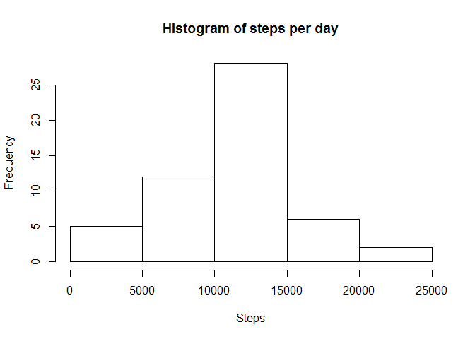

```r
stepsPerDay <- aggregate(steps ~ date, activityData, sum)
hist(stepsPerDay$steps, main="Histogram of steps per day", xlab="Steps")
```

The histogram shows the distribution is roughly bell-shaped with a peak in the range of 10,000 to 15,000 steps.

The code below calculates the mean and median steps per day. Note that the scipen=999 option simply provides a weight in favour of normal numeric presentation rather than scientific notation.

```r
meanSteps <- round(mean(stepsPerDay$steps))
medianSteps <- round(median(stepsPerDay$steps))
options(scipen=999)
```

The mean steps per day is 10766. The median steps per day is 10765.

## What is the average daily activity pattern?

The code below calculates the average steps per interval and produces a time series plot of this data.

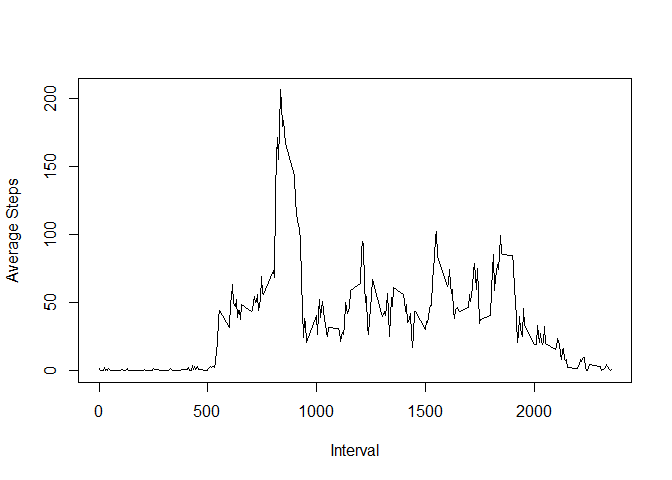

```r
avgStepsPerInterval <- aggregate(steps ~ interval, activityData, mean)
plot(avgStepsPerInterval$interval, avgStepsPerInterval$steps, type="l",
     xlab="Interval", ylab="Average Steps")
```

The plot shows that on average almost no activity occurs during the first 500 intervals of a day or during the last 200. There is a heavy spike in activity around the 800th interval, with moderate activity for the rest of the day.

The code below calculates which interval had the highest number of average steps.

```r
maxInterval <- avgStepsPerInterval[which.max(avgStepsPerInterval$steps), ]
```

The highest average number of steps was 206 and this was found in interval 835.

## Imputing missing values

The code below calculates the number of missing values in the original dataset.

```r
countMissing <- sum(is.na(activityData$steps))
```

The number of missing values in the original dataset is 2304.

The code below creates a new dataset with the missing values replaced by the mean for the corresponding interval.

```r
newSteps <- ifelse(is.na(activityData$steps),
                   avgStepsPerInterval$steps[
                     match(activityData$interval, avgStepsPerInterval$interval)
                   ],
                   activityData$steps)
impActData <- transform(activityData, steps = newSteps)
```

The code below calculates the steps per day using the new dataset and produces a histogram of this data.

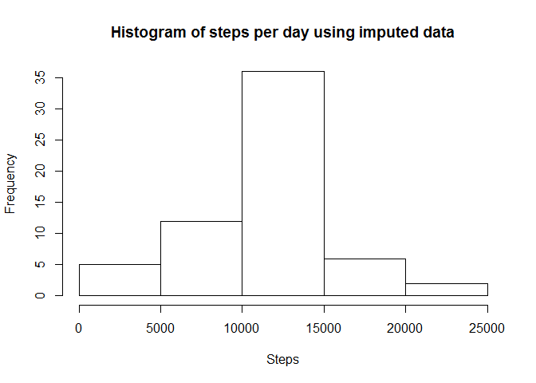

```r
newStepsPerDay <- aggregate(steps ~ date, impActData, sum)
hist(newStepsPerDay$steps, main="Histogram of steps per day using imputed data",
     xlab="Steps")
```

The new histogram has a higher peak compared to the original histogram, which is to be expected given that missing values have been replaced with a measure of central tendency (i.e. the mean by interval).

The code below is used to calculate the new mean and median steps per day.

```r
impMeanSteps <- round(mean(newStepsPerDay$steps))
impMedianSteps <- round(median(newStepsPerDay$steps))
```

The mean steps per day is 10766. The median steps per day is 10766.

In comparison to the non-imputed data, the mean has changed by 0 and the median has changed by 1. As such, replacing missing values has not really changed the measures of central tendency. However, it would have changed measures of average dispersion such as the standard deviation.

## Are there differences in activity patterns between weekdays and weekends?

The code below creates a new column in the imputed dataset to identify whether the record relates to a weekday or a weekend.

```r
impActData$dayType  <- ifelse(weekdays(impActData$date) %in%
                                  c("Saturday", "Sunday"),
                              "weekend",
                              "weekday")
impActData$dayType  <- as.factor(impActData$dayType)
```

The below code calculates the number of average steps for each combination of day type and interval. This summary is then plotted.

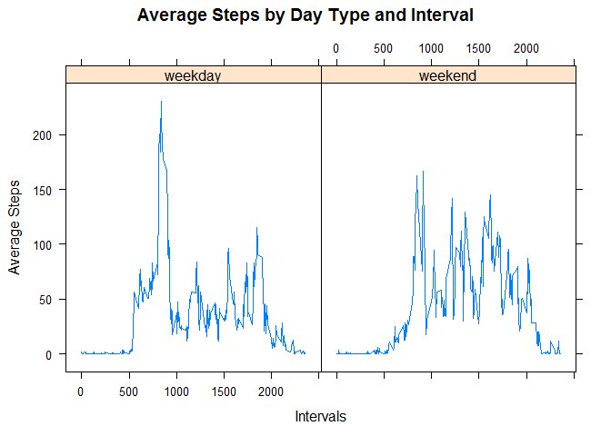

```r
stepsPerDayType <- aggregate(steps ~ dayType + interval, impActData, mean)
library(lattice)
with(stepsPerDayType,
     xyplot(steps ~ interval | dayType,
            type = "l",
            main = "Average Steps by Day Type and Interval",
            xlab = "Intervals",
            ylab = "Average Steps"))
```

The plot shows that there is a spike in activity at around the 800th interval on weekdays whilst there is a more even spread of activity on the weekend.